# Ethereum transaction acceptance based on gas price

## Aim

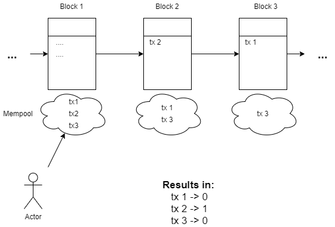

## Data preparation

The original data stream contains events of transactions entering and exiting the Ethereum Mempool. When a transaction is first seen in the Mempool, an event is emitted with the transaction's hash and its status as "pending". Upon successful mining of a transaction, another event is emitted, with the status of the transaction being "confirmed".

From this ongoing stream, one is able to determine how many blocks it takes a transaction to get mined. The transaction events were captured from **block 12108385** to **12108389** of the Ethereum Main Chain. From this, the data to be observed by the model was produced, taking transactions from block 12108386, 12108387, 12108388 and determining, which transactions were mined in the respective next block. Given that the blocks are successive, the demand for block space should've been relatively similar and one could therefore expect, that the gas price estimates for immediate acceptance of transactions should be similar (although the proposed models don't use that fact in any way).

```python
## Data preparation

import numpy as np
import pandas as pd

raw_transactions = pd.read_json("data/transactions_convertible_to_df.json")
raw_transactions = raw_transactions.fillna(0)


# create new data frame for each block with three columns,
# where "minedNextBlock" is either 0 or 1

# block 12108386
observed_txs_block_1 = pd.DataFrame(columns=["hash", "gasPriceGwei", "minedNextBlock"])
for index1, tx1 in raw_transactions.iterrows():
    if tx1["pendingBlockNumber"] == 12108386:
        found_entry_in_next_block = False
        for index2, tx2 in raw_transactions.iterrows():
            if tx1["hash"] == tx2["hash"] and tx1["pendingBlockNumber"] == 12108386 and tx2["blockNumber"] == 12108387 and tx1["status"]=="pending":
                found_entry_in_next_block = True
        if found_entry_in_next_block:
            observed_txs_block_1 = observed_txs_block_1.append({"hash":tx1["hash"], 'gasPriceGwei':tx1["gasPriceGwei"] , "minedNextBlock": 1}, ignore_index=True)
        else:
            observed_txs_block_1 = observed_txs_block_1.append({"hash":tx1["hash"], 'gasPriceGwei':tx1["gasPriceGwei"] , "minedNextBlock": 0}, ignore_index=True)

# block 12108387
observed_txs_block_2 = pd.DataFrame(columns=["hash", "gasPriceGwei", "minedNextBlock"])
for index1, tx1 in raw_transactions.iterrows():
    if tx1["pendingBlockNumber"] == 12108387:
        found_entry_in_next_block = False
        for index2, tx2 in raw_transactions.iterrows():
            if tx1["hash"] == tx2["hash"] and tx1["pendingBlockNumber"] == 12108387 and tx2["blockNumber"] == 12108388 and tx1["status"]=="pending":
                found_entry_in_next_block = True
        if found_entry_in_next_block:
            observed_txs_block_2 = observed_txs_block_2.append({"hash":tx1["hash"], 'gasPriceGwei':tx1["gasPriceGwei"] , "minedNextBlock": 1}, ignore_index=True)
        else:
            observed_txs_block_2 = observed_txs_block_2.append({"hash":tx1["hash"], 'gasPriceGwei':tx1["gasPriceGwei"] , "minedNextBlock": 0}, ignore_index=True)

# block 12108388
observed_txs_block_3 = pd.DataFrame(columns=["hash", "gasPriceGwei", "minedNextBlock"])
for index1, tx1 in raw_transactions.iterrows():
    if tx1["pendingBlockNumber"] == 12108388:
        found_entry_in_next_block = False
        for index2, tx2 in raw_transactions.iterrows():
            if tx1["hash"] == tx2["hash"] and tx1["pendingBlockNumber"] == 12108388 and tx2["blockNumber"] == 12108389 and tx1["status"]=="pending":
                found_entry_in_next_block = True
        if found_entry_in_next_block:
            observed_txs_block_3 = observed_txs_block_3.append({"hash":tx1["hash"], 'gasPriceGwei':tx1["gasPriceGwei"] , "minedNextBlock": 1}, ignore_index=True)
        else:
            observed_txs_block_3 = observed_txs_block_3.append({"hash":tx1["hash"], 'gasPriceGwei':tx1["gasPriceGwei"] , "minedNextBlock": 0}, ignore_index=True)

observed_txs_block_1 = observed_txs_block_1.drop_duplicates(subset='hash', keep="first")
observed_txs_block_2 = observed_txs_block_2.drop_duplicates(subset='hash', keep="first")
observed_txs_block_3 = observed_txs_block_3.drop_duplicates(subset='hash', keep="first")
```

# Model

We want to model the gas price $\theta$, at which the user has a 50% chance of having their transaction be mined in the next block. The aim is to find out, if the results would be reasonable, given the confidence levels if 99%, 95%, 90%, 80%, 70% by the API (same API the data is from).

Our generative model samples the gas price from a Gaussian Prior and uses this estimate to generate a sample which is a positive instance with probability $p=0.5$. This is done through obtaining a success probability through the sigmoid function and then sampling from a Bernoulli distribution (logistic regression).

## Priors

```python
import matplotlib.pyplot as plt
import numpy as np
import scipy.stats as stats
import math
import torch

sensitivity = 0.8

# 70% confidence levels, taken from API
prior_mean_block_1 = torch.tensor(245.0)
prior_sd_block_1 = torch.tensor(20.0)

prior_mean_block_2 = torch.tensor(241.0)
prior_sd_block_2 = torch.tensor(20.0)

prior_mean_block_3 = torch.tensor(253.0)
prior_sd_block_3 = torch.tensor(20.0)

sigma=5
x = np.linspace(prior_mean_block_1 - 20*sigma, prior_mean_block_1 + 20*sigma, 100)
plt.figure(figsize=(12, 8))
plt.plot(x, stats.norm.pdf(x, prior_mean_block_1, prior_sd_block_1))
plt.plot(x, stats.norm.pdf(x, prior_mean_block_2, prior_sd_block_2))
plt.plot(x, stats.norm.pdf(x, prior_mean_block_3, prior_sd_block_3))
plt.xlabel("Gas price")
plt.ylabel("Probability of getting transaction accepted in next block")
plt.legend(["Prior block 1","Prior block 2", "Prior block 3"])
plt.show()
```

[output not shown]

**Note:** Blocks are next to each other in the blockchain, hence 70% confidence levels don't change much between blocks. (Link to API at the end of the notebook)

| Block 1 | Block 2 | Block 3 |
| --- | --- | --- |

## Generative Model

```python
import torch
import pyro
import pyro.distributions as dist


def model(l):
    # Dimension -1 of `l` represents the number of transactions per block
    # Other dimensions are batch dimensions: we indicate this with a plate_stack
    with pyro.plate_stack("plate", l.shape[:-1]):
        theta = pyro.sample("theta", dist.Normal(prior_mean, prior_sd))
        # Share theta across the number of transactions of the block
        theta = theta.unsqueeze(-1)
        # The event shape represents transactions from the same block
        # This define a *logistic regression* model for y
        y = pyro.sample("y", dist.Bernoulli(probs=torch.sigmoid(sensitivity * (theta - l))).to_event(1))
        return

# used for updating posterior after each observation
def make_model(mean, sd):
    def model(l):
        with pyro.plate_stack("plate", l.shape[:-1]):
            theta = pyro.sample("theta", dist.Normal(mean, sd))
            theta = theta.unsqueeze(-1)
            # This define a *logistic regression* model for y
            logit_p = sensitivity * (theta - l)
            y = pyro.sample("y", dist.Bernoulli(logits=logit_p).to_event(1))
            return y
    return model
```

### Example of behaviour of 5 random blocks

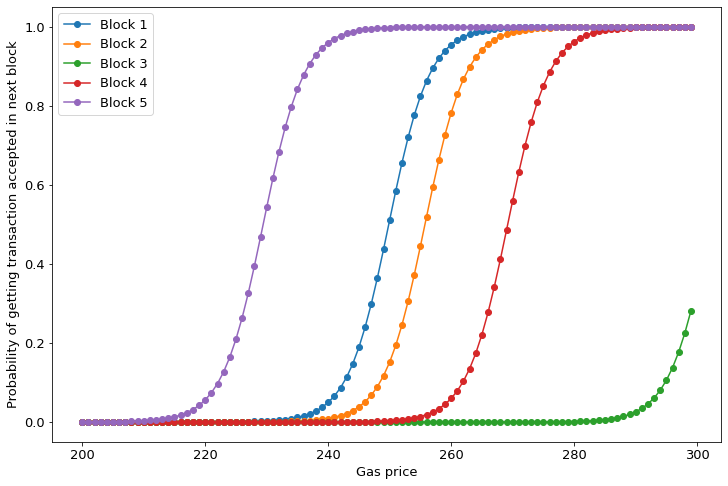

```python
import matplotlib
import matplotlib.pyplot as plt

## 5 random blocks

matplotlib.rcParams.update({'font.size': 22})

# We sample five times from the prior
theta = (prior_mean_block_1 + prior_sd_block_1 * torch.randn((5,1)))
l = torch.arange(200, 300, dtype=torch.float)
# This is the same as using 'logits=' in the prior above
prob = torch.sigmoid(0.3 * (l - theta))

plt.figure(figsize=(12, 8))
matplotlib.rcParams.update({'font.size': 13})
for curve in torch.unbind(prob, 0):
    plt.plot(l.numpy(), curve.numpy(), marker='o')
plt.xlabel("Gas price")
plt.ylabel("Probability of getting transaction accepted in next block")
plt.legend(["Block {}".format(i+1) for i in range(5)])
plt.show()
```

# Inference

We use **Stochastic Variational Inference (SVI)**. For each block, we do traditional SVI and SVI with step-wise visualization of the posterior.

We test 3 settings of the prior for each block:

- mean at 70% confidence level, std = 20
- mean at 70% confidence level, std = 5
- mean at 95% confidence level, std = 50

```python
from torch.distributions.constraints import positive

pyro.clear_param_store()

## guide for inference
def guide(l):
    # The guide is initialised at the prior
    posterior_mean = pyro.param("posterior_mean", prior_mean.clone())
    posterior_sd = pyro.param("posterior_sd", prior_sd.clone(), constraint=positive)
    pyro.sample("theta", dist.Normal(posterior_mean, posterior_sd))
```

```python
import numpy as np
from scipy.stats import norm
import matplotlib.colors as colors
import matplotlib.cm as cmx

def traditional_inference(_l_data, _y_data, out=False):
    pyro.clear_param_store()
    conditioned_model = pyro.condition(model, {"y": _y_data})
    svi = SVI(conditioned_model,
          guide,
          Adam({"lr": .001}),
          loss=Trace_ELBO())
          #num_samples=100) # deprecated
    pyro.clear_param_store()
    num_iters = 10000
    for i in range(num_iters):
        elbo = svi.step(_l_data)
        if i % 500 == 0 and out:
            print("Neg ELBO:", elbo)

def stepwise_inference(_prior_mean, _prior_sd,_data_frame, out=False):
    ys = torch.tensor([])
    ls = torch.tensor([])
    history = [(_prior_mean, _prior_sd)]
    pyro.clear_param_store()
    current_model = make_model(_prior_mean, _prior_sd)

    for i in range(_data_frame.shape[0]):
        #print("Round", i + 1)
        chosen_l = torch.tensor([_data_frame[i:i+1]["gasPriceGwei"].values.item()])

        # Observe transaction
        #print("Observing tx with gp of ", int(chosen_l.item()))
        y = torch.tensor([_data_frame[i:i+1]["minedNextBlock"].values.item()])

        # Store the sequence length and outcome
        ls = torch.cat([ls, chosen_l.expand(1)], dim=0)
        ys = torch.cat([ys, y.expand(1)])

        # learn the posterior using all data seen so far
        conditioned_model = pyro.condition(model, {"y": ys})
        svi = SVI(conditioned_model,
                  guide,
                  Adam({"lr": .001}),
                  loss=Trace_ELBO())
                  #num_samples=100) # deprecated
        num_iters = 1000
        for i in range(num_iters):
            elbo = svi.step(ls)

        history.append((pyro.param("posterior_mean").detach().clone().numpy(),
                        pyro.param("posterior_sd").detach().clone().numpy()))
        current_model = make_model(pyro.param("posterior_mean").detach().clone(),
                                   pyro.param("posterior_sd").detach().clone())
        if out:
            print("Estimate of \u03b8: {:.3f} \u00b1 {:.3f}".format(*history[-1]))

    return history

def draw_single_posterior(_mu, _sd, l=15,r=10, prior_text="Prior"):
    plt.figure(figsize=(12, 6))
    matplotlib.rcParams.update({'font.size': 13})
    mu = _mu
    sigma = math.sqrt(_sd)
    x = np.linspace(mu - l*sigma, mu + l*sigma, 500)
    plt.plot(x, stats.norm.pdf(x, mu, sigma))
    mu = pyro.param("posterior_mean").detach().numpy()
    sigma = math.sqrt(pyro.param("posterior_sd"))


    plt.plot(x, stats.norm.pdf(x, mu, sigma))
    plt.legend([prior_text,"Posterior"])
    plt.show()

def draw_multiple_posteriors(_history, l=150, r = 350):
    matplotlib.rcParams.update({'font.size': 13})
    cmap = plt.get_cmap('winter')
    cNorm  = colors.Normalize(vmin=0, vmax=len(_history)-1)
    scalarMap = cmx.ScalarMappable(norm=cNorm, cmap=cmap)
    plt.figure(figsize=(12, 6))
    x = np.linspace(l, r, r-l)
    for idx, (mean, sd) in enumerate(_history):
        color = scalarMap.to_rgba(idx)
        y = norm.pdf(x, mean, sd)
        plt.plot(x, y, color=color)
        plt.xlabel("$\\theta$")
        plt.ylabel("p.d.f.")
    plt.show()
```

## Block 1

```python
observed_txs_block_1
```

|  | hash | gasPriceGwei | minedNextBlock |
| --- | --- | --- | --- |
| 0 | 0xa5624be9b5d258344935f17a3da30471488a941714f1... | 283 | 1 |
| 1 | 0x7c53da308c69a838024de7f2add831b5f93cd5fbdc8e... | 272 | 0 |
| 2 | 0x525ea5368b83ab54c200a12566e243c5563e5db3f1e5... | 6 | 0 |
| 3 | 0x50b91d4b10c44155f8865b21ed22f70bbbdf819d4ffc... | 186 | 0 |
| 4 | 0x299f55088f491156e6c16e490191a8c6aa0012e9b3f2... | 270 | 1 |
| 5 | 0xbb7af8273b6198539a73eb3a595c9a87403dfa455986... | 218 | 0 |
| 6 | 0x95e8a280a96be14817c5ee0613bdf79d0b8bff4f1d98... | 300 | 1 |
| 7 | 0x738583a6d09e0bd1e4b5b87236343f04088c17bc757d... | 238 | 0 |
| 8 | 0x90084c895167110212f97cdbf058e4c3323c589c907f... | 225 | 0 |
| 9 | 0x2ea1cbbc268a1993ce334504b968c70fb0f38c4aeb4f... | 317 | 1 |
| 10 | 0x36bca79272b48aa1e5822b7b344acc5368084de4ec72... | 215 | 0 |
| 11 | 0x5aed3192347561727798853521423e064c705b5315cb... | 190 | 0 |
| 12 | 0xa0d2ba8927adf9261cafcfbe0f903c5d9385bc48038f... | 258 | 1 |
| 15 | 0xea813e5bfd043fa88f33037edc231018f5fd779c3fd6... | 241 | 0 |
| 16 | 0xd2af828d18a41abf1fca7179801452d9c89d11276e94... | 268 | 1 |
| 17 | 0x95fe532b3e43d6fc0235aab112c2ddaaa8e83c136c8f... | 298 | 1 |
| 18 | 0x22e15b7bd9dbb29e2f7b3ec10bd9a37d517db2c5cd01... | 240 | 0 |
| 19 | 0x91388c399ea96159cca5189eecb810131c45287d5618... | 294 | 1 |
| 20 | 0x6fa33b87957ae12edcb3cf09efdbdde658de7553e467... | 270 | 0 |
| 24 | 0xe7f0e374aaff6720d8409277121d052db0c95e117ae9... | 281 | 0 |

```python
l_data_1 = torch.from_numpy(observed_txs_block_1["gasPriceGwei"].astype("float32").values)
y_data_1 = torch.from_numpy(observed_txs_block_1["minedNextBlock"].astype("float32").values)

pyro.clear_param_store()
```

```python
from pyro.infer import SVI, Trace_ELBO
from pyro.optim import Adam


## with mean=70% confidence, std=20
prior_mean = prior_mean_block_1
prior_sd = prior_sd_block_1

# traditional inference
traditional_inference(l_data_1, y_data_1, out=True)

 # inference with step-wise posterior update
history = stepwise_inference(prior_mean, prior_sd, observed_txs_block_1, out=True)
```

```
Neg ELBO: 223.69627380371094
Neg ELBO: 229.84570407867432
Neg ELBO: 204.86315822601318
Neg ELBO: 175.08966493606567
Neg ELBO: 195.04614877700806
Neg ELBO: 148.13000106811523
Neg ELBO: 151.62466716766357
Neg ELBO: 193.59085845947266
Neg ELBO: 231.30383205413818
Neg ELBO: 235.64446258544922
Neg ELBO: 203.5859661102295
Neg ELBO: 235.7144856452942
Neg ELBO: 201.36315441131592
Neg ELBO: 220.7489161491394
Neg ELBO: 151.02337884902954
Neg ELBO: 219.15795612335205
Neg ELBO: 218.76094388961792
Neg ELBO: 197.90747785568237
Neg ELBO: 149.93526458740234
Neg ELBO: 198.94629764556885
Estimate of θ: 245.452 ± 29.341
Estimate of θ: 245.601 ± 27.445
Estimate of θ: 245.733 ± 25.684
Estimate of θ: 245.713 ± 28.485
Estimate of θ: 245.923 ± 38.336
Estimate of θ: 245.801 ± 46.444
Estimate of θ: 245.830 ± 59.404
Estimate of θ: 245.612 ± 61.726
Estimate of θ: 245.375 ± 65.221
Estimate of θ: 245.178 ± 72.741
Estimate of θ: 245.006 ± 76.589
Estimate of θ: 244.712 ± 82.359
Estimate of θ: 244.490 ± 81.411
Estimate of θ: 244.127 ± 82.209
Estimate of θ: 243.934 ± 84.670
Estimate of θ: 243.812 ± 89.032
Estimate of θ: 243.681 ± 91.948
Estimate of θ: 243.626 ± 93.673
Estimate of θ: 243.418 ± 91.103
Estimate of θ: 243.147 ± 84.131
```

```
Prior:     N(245.000, 20.000)
Posterior: N(243.147, 84.131)
```

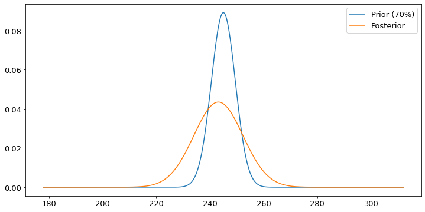

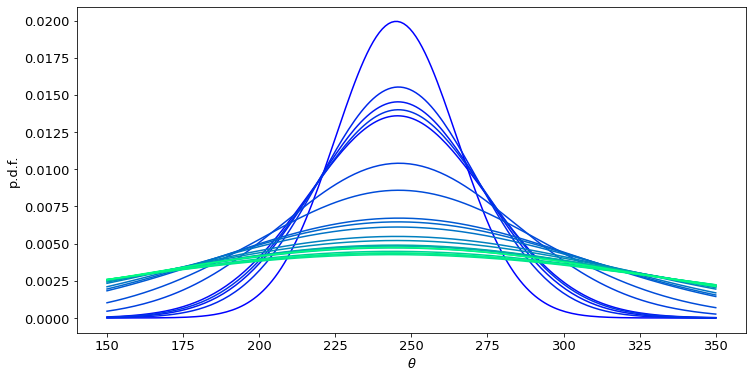

```python
import numpy as np
from scipy.stats import norm
import matplotlib.colors as colors
import matplotlib.cm as cmx


print("Prior:     N({:.3f}, {:.3f})".format(prior_mean, prior_sd))
print("Posterior: N({:.3f}, {:.3f})".format(pyro.param("posterior_mean"),
                                            pyro.param("posterior_sd")))

draw_single_posterior(prior_mean, prior_sd, prior_text="Prior (70%)")
draw_multiple_posteriors(history)
```

**Note:** The bottom chart shows, how the posterior evolves through seeing more data. A curve is drawn after each newly observed transaction in a block. Blue denotes early and green denotes later posteriors.

```python
## with mean=70% confidence, std=5
prior_mean = prior_mean_block_1
prior_sd = prior_sd_block_1 - 15

# traditional inference
traditional_inference(l_data_1, y_data_1)

# inference with step-wise posterior update
history = stepwise_inference(prior_mean, prior_sd, observed_txs_block_1)
```

```
Prior:     N(245.000, 5.000)
Posterior: N(238.565, 18.368)
```

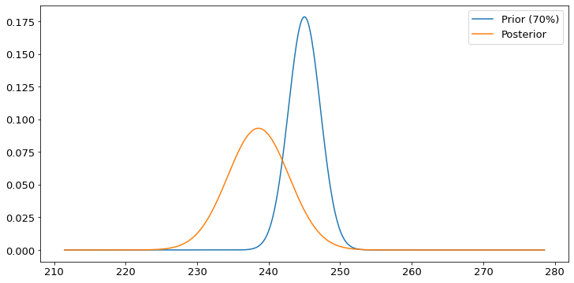

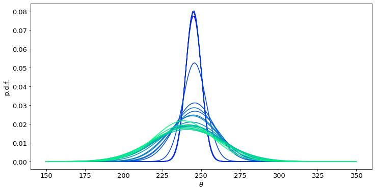

```python
print("Prior:     N({:.3f}, {:.3f})".format(prior_mean, prior_sd))
print("Posterior: N({:.3f}, {:.3f})".format(pyro.param("posterior_mean"),
                                            pyro.param("posterior_sd")))

draw_single_posterior(prior_mean, prior_sd, prior_text="Prior (70%)")
draw_multiple_posteriors(history)
```

```python
## with mean=95% confidence, std=50
prior_mean = prior_mean_block_1 + 15 # 260
prior_sd = prior_sd_block_1 + 30

# traditional inference
traditional_inference(l_data_1, y_data_1)

# inference with step-wise posterior update
history = stepwise_inference(prior_mean, prior_sd, observed_txs_block_1)
```

```
Prior:     N(260.000, 50.000)
Posterior: N(258.210, 192.558)
```

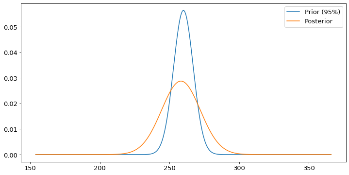

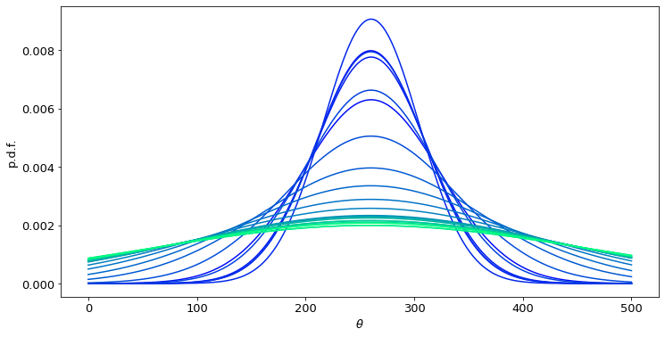

```python
print("Prior:     N({:.3f}, {:.3f})".format(prior_mean, prior_sd))
print("Posterior: N({:.3f}, {:.3f})".format(pyro.param("posterior_mean"),
                                            pyro.param("posterior_sd")))

draw_single_posterior(prior_mean, prior_sd, prior_text="Prior (95%)")
draw_multiple_posteriors(history, l=0, r=500)
```

## Block 2

```python
observed_txs_block_2
```

|  | hash | gasPriceGwei | minedNextBlock |
| --- | --- | --- | --- |
| 0 | 0x17e79aa4c2a6703e3de9611aa2b30585cbfc2f2abaa5... | 229 | 0 |
| 1 | 0xb747ca5b8135954c5d3db074d97a8b663a580f2eccc1... | 263 | 0 |
| 2 | 0x3c059435bb9ccd6edd6d5be8755af3b581a8cd8e27f7... | 263 | 0 |
| 3 | 0x215f0acff72ea17b922d1289cf7729f91582f9ddbb89... | 290 | 1 |
| 4 | 0x4acd2cffd1f4d974676183ee28399dab5cd02ca2870e... | 249 | 0 |
| 5 | 0xf07dd6e99f92cba2d020c20723b131865e61e293bb4b... | 270 | 1 |
| 6 | 0x72ebec688dcf872bd7a07aa08719a8852dccda970d4f... | 238 | 0 |
| 7 | 0x699c69aab8a7d664e780e3635b2dab556c05a394bdf5... | 287 | 1 |
| 8 | 0x55c61102364a615588ef40f23bea7a724eb7f414d834... | 300 | 1 |
| 9 | 0x3ea8a683fb81b36615def1b3012e9d75a91f2d22c4b8... | 300 | 1 |
| 10 | 0x56beaf8c84a744a449e21662a839cafe14e28db3aa96... | 287 | 1 |
| 11 | 0xfc955e77f666a2dcc739baad7ee64a0f1ef86f28acec... | 300 | 1 |
| 12 | 0x333a51d4ef9bf527b2d3a72c2e2e13461cbccc836e7b... | 238 | 0 |
| 13 | 0x04b458483601bed63f32d2c036a40883a1fd9982c512... | 300 | 1 |
| 14 | 0x9b293bad355e206e77e7c2107ff418dcdc4fa9025486... | 250 | 0 |
| 15 | 0x99333e6b928204a1d9104543e3314f1f3938e8e79bab... | 215 | 0 |
| 16 | 0xbea3817e24cd9b13057c26483b7fbadf348b8c423ce6... | 181 | 0 |
| 17 | 0xdc2c402b172b46fdd3bbe021afdd3e98571ada6b5cfc... | 242 | 0 |
| 18 | 0x4de7b60660cfca22eca66f9bc09ec27453b5051abad0... | 300 | 1 |
| 19 | 0x9cf345230d44db0623242dfd8a8ccac06144c9d7893b... | 294 | 1 |
| 20 | 0xc81434c250d6d819a349da0ecd5d4faf11b812c750e6... | 315 | 1 |
| 21 | 0xd35ab04b247ad238f9653dc162347c55b83a94c00ca0... | 300 | 1 |
| 22 | 0xc7a703ff4013da07f29a582e9ac41b7a769492c318a7... | 300 | 1 |
| 35 | 0x447d7a5b9e7d7aef4ca838b1ab720e6c78da71f7d4a4... | 306 | 0 |

```python
prior_mean = prior_mean_block_2
prior_sd = prior_sd_block_2

l_data_2 = torch.from_numpy(observed_txs_block_2["gasPriceGwei"].astype("float32").values)
y_data_2 = torch.from_numpy(observed_txs_block_2["minedNextBlock"].astype("float32").values)

pyro.clear_param_store()
```

```python
## with mean=70% confidence, std=20
prior_mean = prior_mean_block_2
prior_sd = prior_sd_block_2

# traditional inference
traditional_inference(l_data_2, y_data_2)

 # inference with step-wise posterior update
history = stepwise_inference(prior_mean, prior_sd, observed_txs_block_2)
```

```
Prior:     N(241.000, 20.000)
Posterior: N(220.226, 4.325)
```

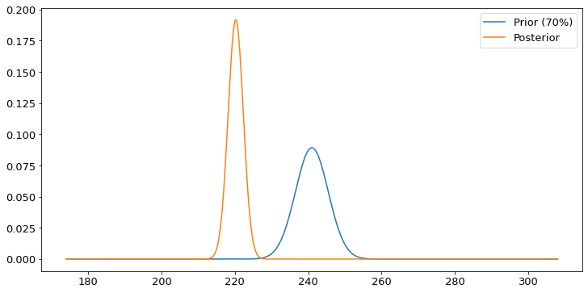

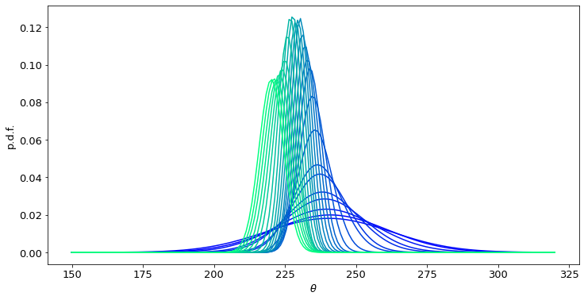

```python
print("Prior:     N({:.3f}, {:.3f})".format(prior_mean, prior_sd))
print("Posterior: N({:.3f}, {:.3f})".format(pyro.param("posterior_mean"),
                                            pyro.param("posterior_sd")))

draw_single_posterior(prior_mean, prior_sd, prior_text="Prior (70%)")
draw_multiple_posteriors(history, l=150,r=320)
```

```python
## with mean=70% confidence, std=5
prior_mean = prior_mean_block_2
prior_sd = prior_sd_block_2 - 15

# traditional inference
traditional_inference(l_data_2, y_data_2)

 # inference with step-wise posterior update
history = stepwise_inference(prior_mean, prior_sd, observed_txs_block_2)
```

```
Prior:     N(241.000, 5.000)
Posterior: N(223.606, 3.477)
```

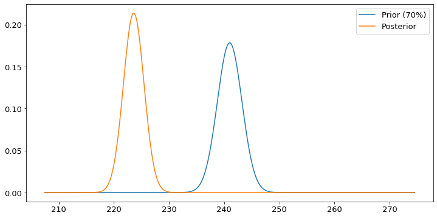

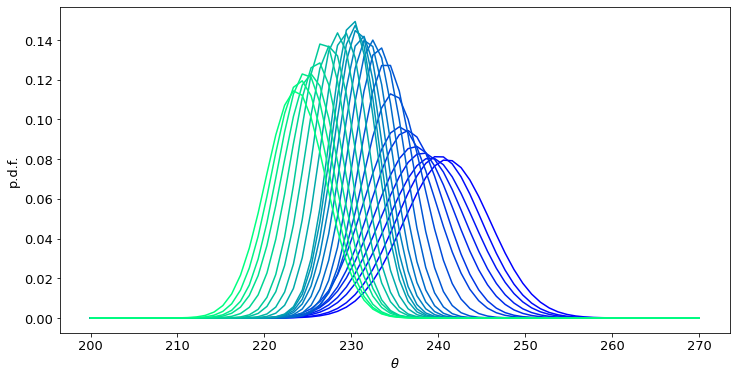

```python
print("Prior:     N({:.3f}, {:.3f})".format(prior_mean, prior_sd))
print("Posterior: N({:.3f}, {:.3f})".format(pyro.param("posterior_mean"),
                                            pyro.param("posterior_sd")))

draw_single_posterior(prior_mean, prior_sd, prior_text="Prior (70%)")
draw_multiple_posteriors(history, l=200, r=270)
```

```python
## with mean=95% confidence, std=50
prior_mean = prior_mean_block_2+ 13 # 254
prior_sd = prior_sd_block_2 + 30

# traditional inference
traditional_inference(l_data_2, y_data_2)

 # inference with step-wise posterior update
history = stepwise_inference(prior_mean, prior_sd, observed_txs_block_2)
```

```
Prior:     N(254.000, 50.000)
Posterior: N(249.761, 190.302)
```

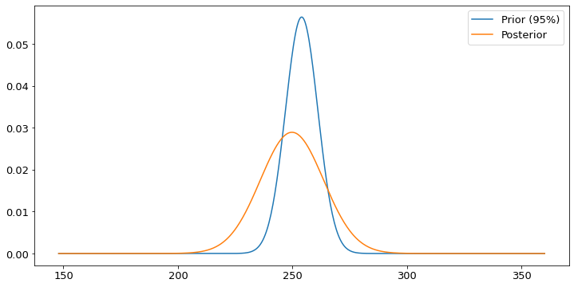

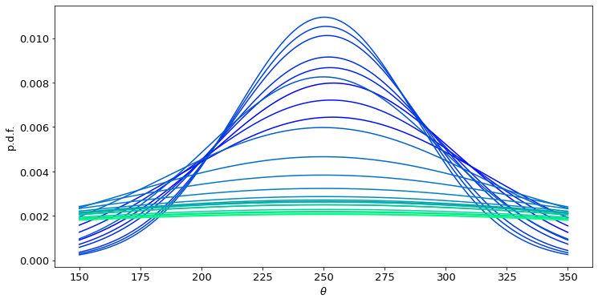

```python
print("Prior:     N({:.3f}, {:.3f})".format(prior_mean, prior_sd))
print("Posterior: N({:.3f}, {:.3f})".format(pyro.param("posterior_mean"),
                                            pyro.param("posterior_sd")))

draw_single_posterior(prior_mean, prior_sd, prior_text="Prior (95%)")
draw_multiple_posteriors(history)
```

## Block 3

```python
observed_txs_block_3
```

|  | hash | gasPriceGwei | minedNextBlock |
| --- | --- | --- | --- |
| 0 | 0x0b7a6f2f59423b557398ce7926967a4a45e44c16857a... | 287 | 1 |
| 1 | 0x4e867e57608484fe1f5ec6e33770c78256ebe2df7766... | 244 | 0 |
| 2 | 0xc03633ceb2c3fba1e6de0f2a65133fb54d2218561112... | 261 | 0 |
| 3 | 0x9d56200c3888a1092b395b1b48216a9009d054475be8... | 237 | 0 |
| 4 | 0x7d73838c65a8d5567f591943e2734087b71c03f39108... | 249 | 0 |
| 5 | 0xae2917dc7f9674687b1e0f3de509c8d750a1429f4407... | 258 | 0 |
| 6 | 0x4b6f849b47c9cf64e59b030f0edc02b4a8e1bd2503f9... | 300 | 1 |
| 7 | 0x72564cc98aaa5d1e5c720346dcf55edd7043aa42c6e8... | 306 | 1 |
| 8 | 0x4c67521631f798da48a5f065aed2718c5629ff812e81... | 300 | 1 |
| 9 | 0x6955ed5535e89b70a3faf8a8799a6dbcea5b6ad53419... | 255 | 0 |
| 10 | 0xf3a7f77ef5a10c4b715c93007741601d3013d66821c1... | 260 | 0 |
| 11 | 0x98cab0d38cc822be0e1759254ed1f6c8e2bde4dfa5a9... | 300 | 1 |
| 12 | 0x4830571c1737e10b51aa953e9db736294851805c684e... | 269 | 1 |
| 13 | 0xb0026e8720d61c3f266df04a3048e502e95bb97a0e07... | 249 | 0 |
| 14 | 0xf224feb95ae4bb2c51aec769aef032662dece057f05b... | 287 | 1 |
| 15 | 0xbef1b210661fc207a4590527c280c518a4ffb07e6583... | 300 | 1 |
| 16 | 0x11b57285f22f420f1b3a4d8a60bd1fb82740f1ff4663... | 150 | 0 |
| 17 | 0x33d05e1c93473a8841fe9f1d9642b999f12f78ce7bde... | 180 | 0 |
| 18 | 0x9023d8293a39231b03b1c4a37e2080e6ce90c2d127b3... | 273 | 0 |
| 19 | 0x6f635b2233190fb250ae3e5d1a8381152a77c6476477... | 266 | 1 |
| 20 | 0x69c1bdf7cc49120ae743bfbe6cec042fca65d3cf5be3... | 7 | 0 |
| 21 | 0x426815b5c6202287229d8bb0cf17c6c9d4a8dcfb25f6... | 300 | 1 |
| 22 | 0x5b9f40646305563e43775fbf79b994cdbbcc3bc7b1d8... | 231 | 0 |
| 23 | 0xe30683aff4a75be25e27c54219edd9c66ecbbb9ab646... | 300 | 1 |
| 24 | 0xfba927c74c3d4bbbee6a727b1bf6ace468c259c83675... | 242 | 0 |
| 25 | 0xbcdab99f71e810fc5c04605f3274eaa8aea3c460ee0b... | 240 | 0 |
| 26 | 0xe2693e8ae8c336d0bfb4a05a18b5b73a4da5e63fb19d... | 248 | 0 |
| 27 | 0x4f19c3ba1d8f93e15f5f1e2ec94c1c4e2fbedcc12622... | 306 | 1 |
| 28 | 0x9e56e99959bb3e5825fb83a71e3c1a1ea0878684198d... | 248 | 0 |
| 29 | 0x6a5768139336b1bed5023e5ecd58f8f1a4c961b992aa... | 263 | 0 |
| 30 | 0xcc4cde62a2063559e1cc5713333858c9684a323a3e13... | 261 | 0 |
| 31 | 0xaa17a5aa500f63d07795c20053794e72fdc1aad1bd12... | 306 | 1 |
| 32 | 0xd4aa19a69a12813634cfaa0c35f7b50837bd1d740be5... | 450 | 1 |
| 33 | 0xd2db5d14b4d3e4ae887591f40016b4b43f48e4df6021... | 251 | 0 |
| 34 | 0x686b623bb7af92788674c578c92ca2cf4a01c627b445... | 248 | 0 |
| 35 | 0xe33dd7aec32626ab380e122e127178bfefd84a732df7... | 240 | 0 |
| 36 | 0x0c165da03b44f6b112730a2adca53523a2177c2fc0c4... | 226 | 0 |
| 37 | 0xbde4c94a30191a9dcefcc7278c00080716f2f586cd4b... | 306 | 1 |
| 38 | 0xd391498e0ffc29e0c36441bc93e76e65bc58b8c063fe... | 279 | 0 |
| 39 | 0x5b69a8086abec03fb49e768e5db225b1b76090a51827... | 164 | 0 |
| 40 | 0x36848596b7122685fecf05ee43821967bfb20596b032... | 181 | 0 |
| 43 | 0x9dbb25b37268c46d00bd157f3468e6511a700a6d2f27... | 269 | 0 |

```python
prior_mean = prior_mean_block_3
prior_sd = prior_sd_block_3

l_data_3 = torch.from_numpy(observed_txs_block_3["gasPriceGwei"].astype("float32").values)
y_data_3 = torch.from_numpy(observed_txs_block_3["minedNextBlock"].astype("float32").values)

pyro.clear_param_store()
```

```python
## with mean=70% confidence, std=20
prior_mean = prior_mean_block_3
prior_sd = prior_sd_block_3

# traditional inference
traditional_inference(l_data_3, y_data_3)

 # inference with step-wise posterior update
history = stepwise_inference(prior_mean, prior_sd, observed_txs_block_3)
```

```
Prior:     N(253.000, 20.000)
Posterior: N(223.536, 3.362)
```

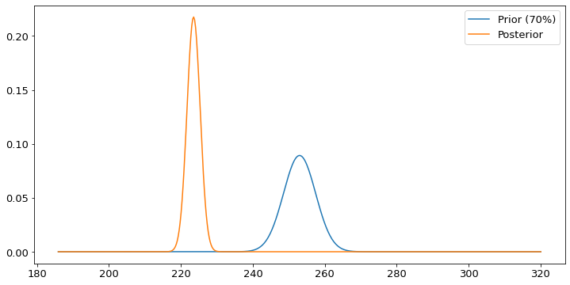

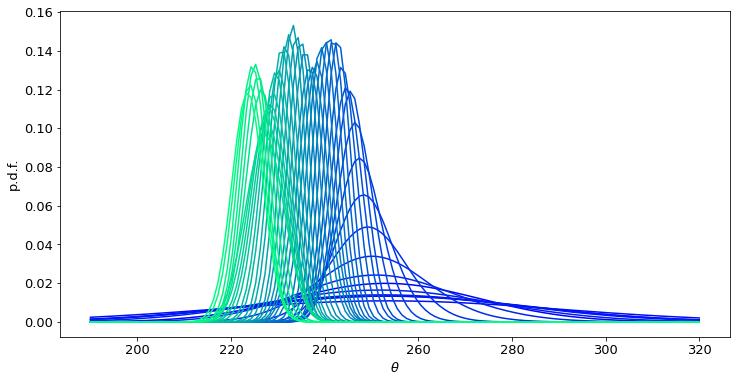

```python
print("Prior:     N({:.3f}, {:.3f})".format(prior_mean, prior_sd))
print("Posterior: N({:.3f}, {:.3f})".format(pyro.param("posterior_mean"),
                                            pyro.param("posterior_sd")))

draw_single_posterior(prior_mean, prior_sd, prior_text="Prior (70%)")
draw_multiple_posteriors(history, l=190, r= 320)
```

```python
## with mean=70% confidence, std=5
prior_mean = prior_mean_block_3
prior_sd = prior_sd_block_3 - 15

# traditional inference
traditional_inference(l_data_3, y_data_3)

# inference with step-wise posterior update
history = stepwise_inference(prior_mean, prior_sd, observed_txs_block_3)
```

```
Prior:     N(253.000, 5.000)
Posterior: N(230.072, 2.279)
```

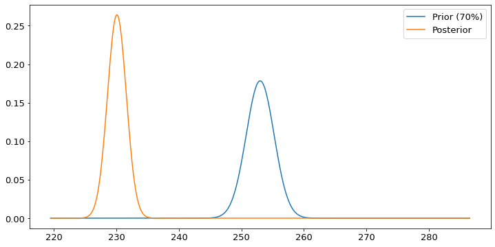

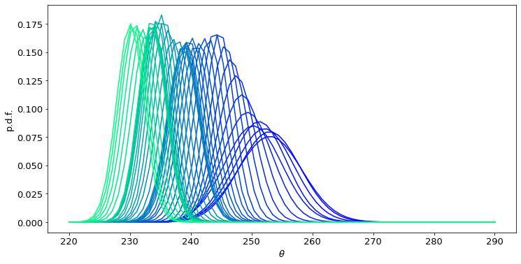

```python
print("Prior:     N({:.3f}, {:.3f})".format(prior_mean, prior_sd))
print("Posterior: N({:.3f}, {:.3f})".format(pyro.param("posterior_mean"),
                                            pyro.param("posterior_sd")))

draw_single_posterior(prior_mean, prior_sd, prior_text="Prior (70%)")
draw_multiple_posteriors(history, l=220, r=290)
```

```python
## with mean=95% confidence, std=50
prior_mean = prior_mean_block_3 + 19 # 272
prior_sd = prior_sd_block_3 + 30

# traditional inference
traditional_inference(l_data_3, y_data_3)

 # inference with step-wise posterior update
history = stepwise_inference(prior_mean, prior_sd, observed_txs_block_3)
```

```
Prior:     N(272.000, 50.000)
Posterior: N(267.420, 252.755)
```

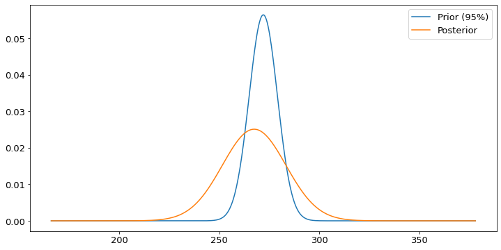

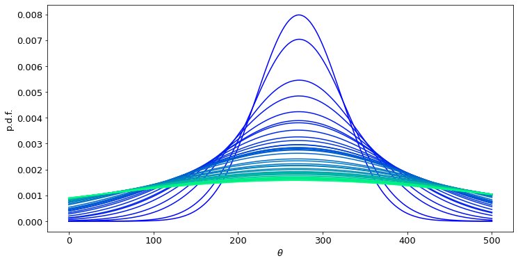

```python
print("Prior:     N({:.3f}, {:.3f})".format(prior_mean, prior_sd))
print("Posterior: N({:.3f}, {:.3f})".format(pyro.param("posterior_mean"),
                                            pyro.param("posterior_sd")))

draw_single_posterior(prior_mean, prior_sd, prior_text="Prior (95%)")
draw_multiple_posteriors(history, l=0, r=500)
```

**Possible improvements:**

- The sensitivity (slope) of the sigmoid function could be learned, instead of fixed
- Another variable that has influence on a reasonable estimate is the time since last mined block, since the later in the block, the more confidence we have in the fact that no new more highly priced transactions enter the Mempool, out-competing us for blockspace. But since we would have needed to sample the time after each transaction event, the data collection was not reasonable (collected in real-time)

**Sources:**

- code adapted from https://pyro.ai/examples/working_memory.html
- tx event data (recorded live from): https://explorer.blocknative.com/?v=1.13.1&0=ethereum&1=main&s=%7B%22name%22%3A%22Tether%22%2C%22address%22%3A%220xdac17f958d2ee523a2206206994597c13d831ec7%22%7D&s=%7B%22name%22%3A%22USDC%22%2C%22address%22%3A%220xa0b86991c6218b36c1d19d4a2e9eb0ce3606eb48%22%7D&s=%7B%22name%22%3A%22DAI%22%2C%22address%22%3A%220x6b175474e89094c44da98b954eedeac495271d0f%22%7D&fr=%7B%22contractCall.decimalValue%22%3A%7B%22gte%22%3A5000%7D%7D
- additional gas estimations for reference ("data/external_gas_recommendations.js") https://api.anyblock.tools/ethereum/latest-minimum-gasprice/